# INTRODUCTION TO GGPLOT2: THEMES

After getting familiar with the data, reduce it to a compact and understandable format for a lay audience:

```r
gm2007_high <- gm2007_full %>%
  arrange(lifeExp) %>%
  top_n(10, wt = lifeExp)
gm2007_low <- gm2007_full %>%
  arrange(lifeExp) %>%
  top_n(-10, wt = lifeExp)
gm2007 <- rbind(gm2007_low, gm2007_high)
glimpse(gm2007)
```

```
## Rows: 20
## Columns: 3
## $ country   <fct> "Swaziland", "Mozambique", "Zambia", "Sierra Leone", "Les...
## $ lifeExp   <dbl> 39.613, 42.082, 42.384, 42.568, 42.592, 42.731, 43.487, 4...
## $ continent <fct> Africa, Africa, Africa, Africa, Africa, Africa, Africa, A...
```

In this form we only have 20 observations, the top 10 and bottom observations.

Mapping the country to the y axis, so that it is easy to read. Mapping life expectancy onto both x axis and color is redundant, but helps a lay audience. The line segments add some perspective and is sometimes referred to as a lollipop plot when used with points.

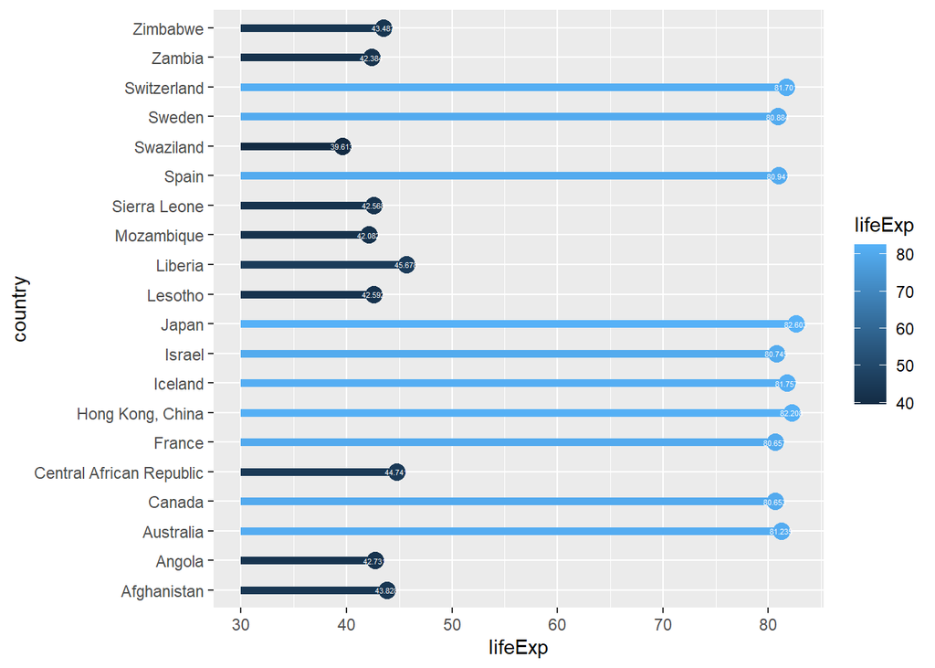

```r
ggplot(gm2007, aes(lifeExp, country,
                   col = lifeExp)) +
  geom_point(size = 4) +
  geom_segment(aes(xend = 30,         # adds line segments
                   yend = country),
               size = 2) +
  geom_text(aes(label = lifeExp),     # add labels on the points.
                color = "white",
                size = 1.5)
```

Set a color scale for more magazin-quality effect:

```r
library(RColorBrewer)
palette <- brewer.pal(5, "RdYlBu")[-(2:4)]
```

Modify the scales of the lollipop plot:

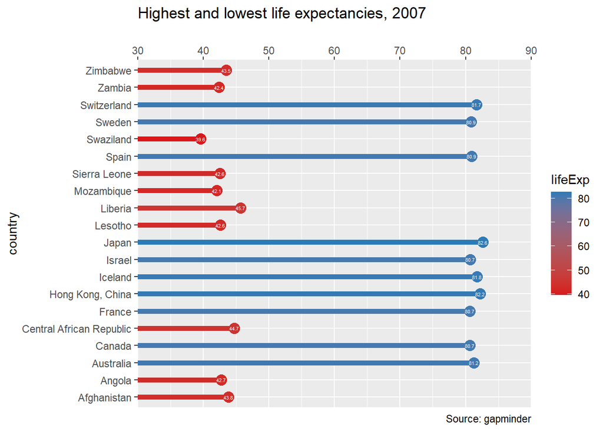

```r
plt_country_vs_lifeExp <-
  ggplot(gm2007, aes(lifeExp, country,
                   col = lifeExp)) +
  geom_point(size = 4) +
  geom_segment(aes(xend = 30,
                   yend = country),
               size = 2) +
  geom_text(aes(label = round(lifeExp, 1)),
            color = "white",
            size = 1.5) +
  scale_x_continuous("",
                     expand = c(0,0),
                     limits = c(30,90),
                     position = "top") +
  scale_color_gradientn(colors = palette) +
  labs(title = "Highest and lowest life expectancies, 2007",
       caption = "Source: gapminder")
plt_country_vs_lifeExp
```

Typically, we are happy to just read a value from the axis, but adding the actual value using `geom_text` layer makes it immediately more intuitive fo inexperienced viewers.

The following values have been calculated for embellishments to the plot:

```r
global_mean <- mean(gm2007_full$lifeExp)
x_start <- global_mean + 4
y_start <- 5.5
x_end <- global_mean
y_end <- 7.5
```

Clean up the plot by removing non-data ink and unnecessary buffering:

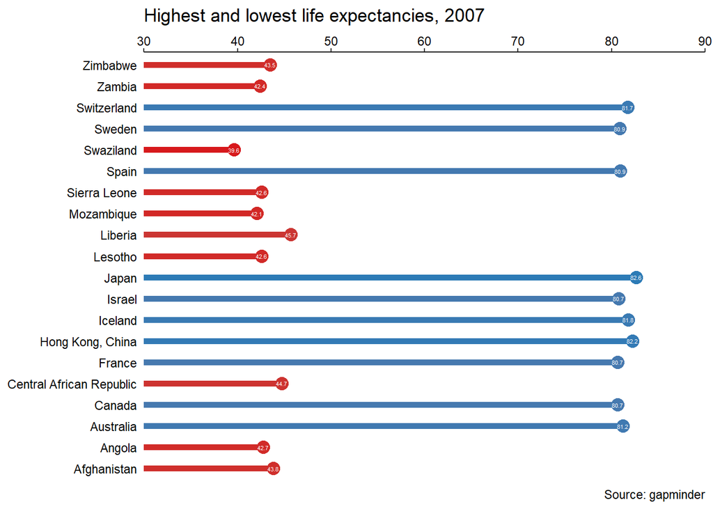

```r
plt_country_vs_lifeExp <- plt_country_vs_lifeExp +
  theme_classic() +
  theme(axis.line.y = element_blank(),
        axis.ticks.y = element_blank(),
        axis.text = element_text(color = "black"),
        axis.title = element_blank(),
        legend.position = "none")
plt_country_vs_lifeExp
```

Use `geom_vline()` to add a vertical line and label the threshold with `annotate()`:

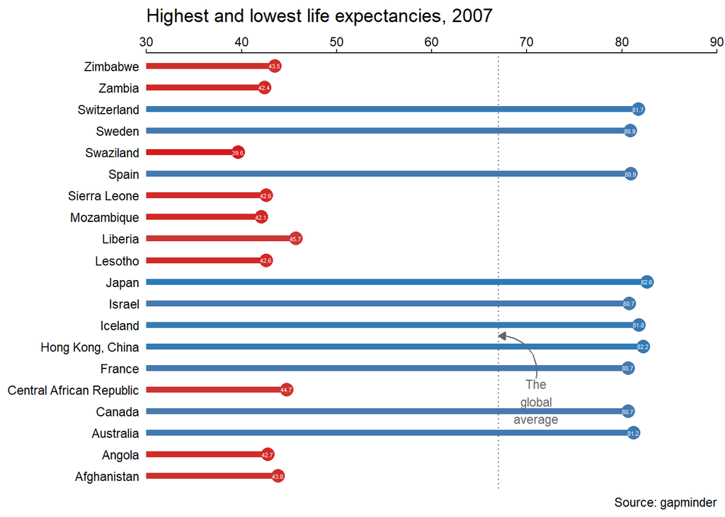

```r
plt_country_vs_lifeExp +
  geom_vline(xintercept = global_mean,
             color = "grey40",
             linetype = 3) +
  annotate("text", x = x_start, y = y_start,
           label = "The\nglobal\naverage",
           vjust = 1,
           size = 3,
           color = "grey40") +
  annotate("curve", x = x_start, y = y_start,
          xend = x_end, yend = y_end,
          arrow = arrow(length = unit(0.2, "cm"), type = "closed"),
          color = "grey40")
```